# Modern Data Mining - HW 2

Antina Lee

Maria Diaz Ortiz

Joseph Haymaker

## Problem 0

**Review the code and concepts covered during lecture: model selection and penalized regression through elastic net.**

## Problem 1: Model Selection

**Do ISLR, page 262, problem 8, and write up the answer here. This question is designed to help understanding of model selection through simulations.**

```r
#p.262 #8
#=============================PART A============================
set.seed(1)
x <- rnorm(100)
epsilon <- rnorm(100)
```

```r
#=============================PART B============================
#(b) Generate a response vector Y of length n = 100 according to
#the model
b0 <- 5 #all numbers randomly assigned
b1 <- 3
b2 <- 4
b3 <- 7.2

y <- b0 + b1*x + b2* x^2 + b3* x^3 + epsilon
```

```r
#=============================PART C==========================
# Use the regsubsets() function to perform best subset selection
# in order to choose the best model containing the predictors
# X,X2, . . .,X10. What is the best model obtained according to
# Cp, BIC, and adjusted R2? Show some plots to provide evidence
# for your answer, and report the coefficients of the best model obtained.
# Note you will need to use the data.frame() function to
# create a single data set containing both X and Y .

dataset <- data.frame(y = y, x = x)
summary(dataset)
```

```
##        y                 x
##  Min.   :-60.888   Min.   :-2.2147
##  1st Qu.:  3.173   1st Qu.:-0.4942
##  Median :  6.000   Median : 0.1139
##  Mean   : 10.048   Mean   : 0.1089
##  3rd Qu.: 10.907   3rd Qu.: 0.6915
##  Max.   :135.435   Max.   : 2.4016
```

```r
regfit.fullmodel=regsubsets(y ~ x + I(x^2) + I(x^3) + I(x^4) + I(x^5) + I(x^6) + I(x^7) + I(x^8) + I(x^9) + I(x^10), data=dataset,nvmax=10)
fullmod.sum=summary(regfit.fullmodel)
names(fullmod.sum)
```

```
## [1] "which"  "rsq"    "rss"    "adjr2"  "cp"     "bic"    "outmat" "obj"
```

```r
fullmod.sum$rsq
```

```
##  [1] 0.9600927 0.9937229 0.9982703 0.9983360 0.9983439 0.9983473 0.9983511
##  [8] 0.9983624 0.9983627 0.9983655
```

```r
par(mfrow=c(2,2))
plot(fullmod.sum$rss,xlab="number of variables", ylab="RSS",type="l")
plot(fullmod.sum$adjr2,xlab="Number of variables", ylab="Adjusted Rsq",type = "l")
#adjusted Rsq highest at 4 variables
which.max(fullmod.sum$adjr2)
```

```
## [1] 4
```

```r
points(4,fullmod.sum$adjr2[4], col="red",cex=2,pch=20)

#Cp and BIC stats
plot(fullmod.sum$cp,xlab="number of variables",ylab="Cp", type="l")
which.min(fullmod.sum$cp)
```

```
## [1] 4
```

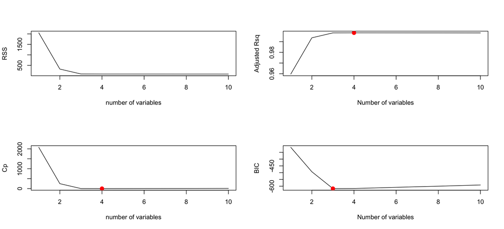

```r
points(4,fullmod.sum$cp[4],col="red",cex=2,pch=20)
plot(fullmod.sum$bic,xlab="Number of variables",ylab="BIC",type = "l")
points(which.min(fullmod.sum$bic), fullmod.sum$bic[which.min(fullmod.sum$bic)],col="red",cex=2,pch=20)
```

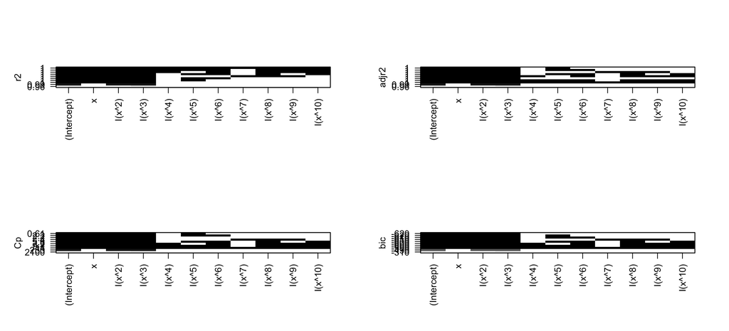

```r
plot(regfit.fullmodel,scale="r2")
plot(regfit.fullmodel,scale="adjr2")
plot(regfit.fullmodel,scale = "Cp")
plot(regfit.fullmodel,scale="bic")
```

```r
#coefficients for 4 variable model
coef(regfit.fullmodel,4)
```

```
## (Intercept)           x      I(x^2)      I(x^3)      I(x^5)
##  5.07200775  3.38745596  3.84575641  6.75797426  0.08072292
```

```r
#===============================PART D==========================
# Repeat (c), using forward stepwise selection and also using backwards
# stepwise selection. How does your answer compare to the
# results in (c)?

#<<<<<<<<<<<<<<<<<<<<<<FORWARD STEPWISE SELECTION>>>>>>>>>>>>>>>>>>>
regfit.forward=regsubsets(y ~ x + I(x^2) + I(x^3) + I(x^4) + I(x^5) + I(x^6) + I(x^7) + I(x^8) + I(x^9) + I(x^10), data=dataset,nvmax=10,method = "forward")
forwardmod.sum=summary(regfit.forward)
forwardmod.sum
```

```
## Subset selection object
## Call: regsubsets.formula(y ~ x + I(x^2) + I(x^3) + I(x^4) + I(x^5) +
##     I(x^6) + I(x^7) + I(x^8) + I(x^9) + I(x^10), data = dataset,
##     nvmax = 10, method = "forward")
## 10 Variables  (and intercept)
##         Forced in Forced out
## x           FALSE      FALSE
## I(x^2)      FALSE      FALSE
## I(x^3)      FALSE      FALSE
## I(x^4)      FALSE      FALSE
## I(x^5)      FALSE      FALSE
## I(x^6)      FALSE      FALSE
## I(x^7)      FALSE      FALSE
## I(x^8)      FALSE      FALSE
## I(x^9)      FALSE      FALSE
## I(x^10)     FALSE      FALSE
## 1 subsets of each size up to 10
## Selection Algorithm: forward
##           x   I(x^2) I(x^3) I(x^4) I(x^5) I(x^6) I(x^7) I(x^8) I(x^9)
## 1  ( 1 )  " " " "    "*"    " "    " "    " "    " "    " "    " "
## 2  ( 1 )  " " "*"    "*"    " "    " "    " "    " "    " "    " "
## 3  ( 1 )  "*" "*"    "*"    " "    " "    " "    " "    " "    " "
## 4  ( 1 )  "*" "*"    "*"    " "    "*"    " "    " "    " "    " "
## 5  ( 1 )  "*" "*"    "*"    " "    "*"    "*"    " "    " "    " "
## 6  ( 1 )  "*" "*"    "*"    " "    "*"    "*"    " "    " "    "*"
## 7  ( 1 )  "*" "*"    "*"    " "    "*"    "*"    "*"    " "    "*"
## 8  ( 1 )  "*" "*"    "*"    " "    "*"    "*"    "*"    "*"    "*"
## 9  ( 1 )  "*" "*"    "*"    " "    "*"    "*"    "*"    "*"    "*"
## 10  ( 1 ) "*" "*"    "*"    "*"    "*"    "*"    "*"    "*"    "*"
##           I(x^10)
## 1  ( 1 )  " "
## 2  ( 1 )  " "
## 3  ( 1 )  " "
## 4  ( 1 )  " "
## 5  ( 1 )  " "
## 6  ( 1 )  " "
## 7  ( 1 )  " "
## 8  ( 1 )  " "
## 9  ( 1 )  "*"
## 10  ( 1 ) "*"
```

```r
par(mfrow = c(2, 2))
# Cp - 4 vars
plot(forwardmod.sum$cp, xlab = "Number of variables", ylab = "C_p", type = "l")
points(which.min(forwardmod.sum$cp), forwardmod.sum$cp[which.min(forwardmod.sum$cp)], col = "red", cex = 2, pch = 20)
# BIC --indicates 3 vars best
plot(forwardmod.sum$bic, xlab = "Number of variables", ylab = "BIC", type = "l")
points(which.min(forwardmod.sum$bic), forwardmod.sum$bic[which.min(forwardmod.sum$bic)], col = "red", cex = 2, pch = 20)
# adj Rsq - 4 vars
plot(forwardmod.sum$adjr2, xlab = "Number of variables", ylab = "Adjusted Rsq", type = "l")
points(which.max(forwardmod.sum$adjr2), forwardmod.sum$adjr2[which.max(forwardmod.sum$adjr2)], col = "red", cex = 2, pch = 20)

coef(regfit.forward,3)
```

```
## (Intercept)           x      I(x^2)      I(x^3)
##    5.061507    2.975280    3.876209    7.217639
```

```r
# (Intercept)           x      I(x^2)      I(x^3)
# 5.061507    2.975280    3.876209    7.217639
coef(regfit.forward,4)
```

```
## (Intercept)           x      I(x^2)      I(x^3)      I(x^5)
##  5.07200775  3.38745596  3.84575641  6.75797426  0.08072292
```

```r
# (Intercept)           x      I(x^2)      I(x^3)      I(x^5)
# 5.07200775  3.38745596  3.84575641  6.75797426  0.08072292
```

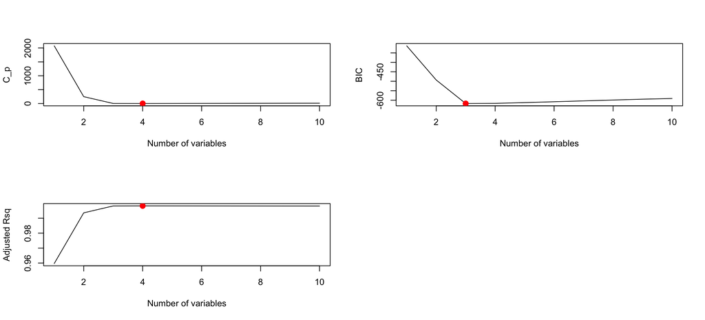

```r
#<<<<<<<<<<<<<<<<<<<<<<BACKWARDS STEPWISE SELECTION>>>>>>>>>>>>>>>>>>>
regfit.backward=regsubsets(y ~ x + I(x^2) + I(x^3) + I(x^4) + I(x^5) + I(x^6) + I(x^7) + I(x^8) + I(x^9) + I(x^10), data=dataset,nvmax=10,method = "backward")
backwardmod.sum=summary(regfit.backward)
backwardmod.sum
```

```
## Subset selection object
## Call: regsubsets.formula(y ~ x + I(x^2) + I(x^3) + I(x^4) + I(x^5) +
##     I(x^6) + I(x^7) + I(x^8) + I(x^9) + I(x^10), data = dataset,
##     nvmax = 10, method = "backward")
## 10 Variables  (and intercept)
##         Forced in Forced out
## x           FALSE      FALSE
## I(x^2)      FALSE      FALSE
## I(x^3)      FALSE      FALSE
## I(x^4)      FALSE      FALSE
## I(x^5)      FALSE      FALSE
## I(x^6)      FALSE      FALSE
## I(x^7)      FALSE      FALSE
## I(x^8)      FALSE      FALSE
## I(x^9)      FALSE      FALSE
## I(x^10)     FALSE      FALSE
## 1 subsets of each size up to 10
## Selection Algorithm: backward
##           x   I(x^2) I(x^3) I(x^4) I(x^5) I(x^6) I(x^7) I(x^8) I(x^9)
## 1  ( 1 )  " " " "    "*"    " "    " "    " "    " "    " "    " "
## 2  ( 1 )  " " "*"    "*"    " "    " "    " "    " "    " "    " "
## 3  ( 1 )  "*" "*"    "*"    " "    " "    " "    " "    " "    " "
## 4  ( 1 )  "*" "*"    "*"    " "    " "    " "    " "    " "    "*"
## 5  ( 1 )  "*" "*"    "*"    " "    " "    " "    " "    "*"    "*"
## 6  ( 1 )  "*" "*"    "*"    " "    " "    " "    " "    "*"    "*"
## 7  ( 1 )  "*" "*"    "*"    " "    " "    "*"    " "    "*"    "*"
## 8  ( 1 )  "*" "*"    "*"    "*"    " "    "*"    " "    "*"    "*"
## 9  ( 1 )  "*" "*"    "*"    "*"    "*"    "*"    " "    "*"    "*"
## 10  ( 1 ) "*" "*"    "*"    "*"    "*"    "*"    "*"    "*"    "*"
##           I(x^10)
## 1  ( 1 )  " "
## 2  ( 1 )  " "
## 3  ( 1 )  " "
## 4  ( 1 )  " "
## 5  ( 1 )  " "
## 6  ( 1 )  "*"
## 7  ( 1 )  "*"
## 8  ( 1 )  "*"
## 9  ( 1 )  "*"
## 10  ( 1 ) "*"
```

```r
par(mfrow = c(2, 2))
# Cp -4  vars
plot(backwardmod.sum$cp, xlab = "Number of variables", ylab = "C_p", type = "l")
points(which.min(backwardmod.sum$cp), backwardmod.sum$cp[which.min(backwardmod.sum$cp)], col = "red", cex = 2, pch = 20)
# BIC --indicates 3 vars best
plot(backwardmod.sum$bic, xlab = "Number of variables", ylab = "BIC", type = "l")
points(which.min(backwardmod.sum$bic), backwardmod.sum$bic[which.min(backwardmod.sum$bic)], col = "red", cex = 2, pch = 20)
# adj Rsq - 4 vars
plot(backwardmod.sum$adjr2, xlab = "Number of variables", ylab = "Adjusted Rsq", type = "l")
points(which.max(backwardmod.sum$adjr2), backwardmod.sum$adjr2[which.max(backwardmod.sum$adjr2)], col = "red", cex = 2, pch = 20)

coef(regfit.backward,3)
```

```
## (Intercept)           x      I(x^2)      I(x^3)
##    5.061507    2.975280    3.876209    7.217639
```

```r
# (Intercept)           x      I(x^2)      I(x^3)
# 5.061507    2.975280    3.876209    7.217639
coef(regfit.backward,4)
```

```
## (Intercept)           x      I(x^2)      I(x^3)      I(x^9)
## 5.079236362 3.231905828 3.833494180 7.019555807 0.001290827
```

```r
# (Intercept)           x      I(x^2)      I(x^3)      I(x^9)
# 5.079236362 3.231905828 3.833494180 7.019555807 0.001290827
```

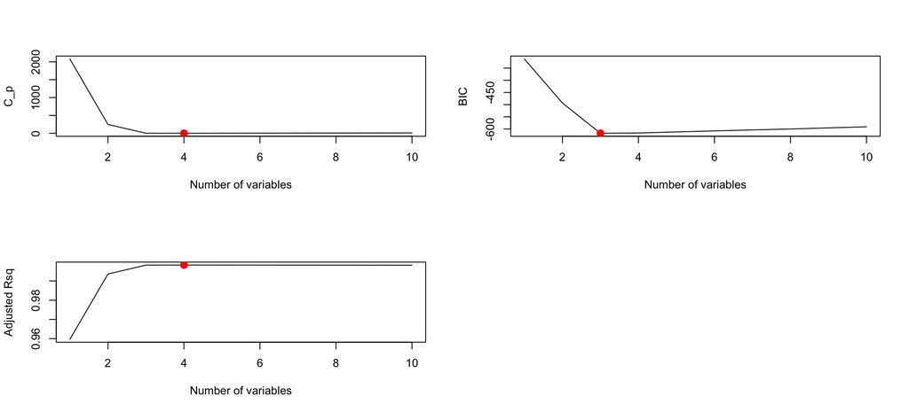

```r
#==============================PART E==========================
# (e) Now fit a lasso model to the simulated data, again using X,X2,
# . . . , X10 as predictors. Use cross-validation to select the optimal
# value of λ. Create plots of the cross-validation error as a function
# of λ. Report the resulting coefficient estimates, and discuss the
# results obtained.

x_matrix = model.matrix(y ~ x + I(x^2) + I(x^3) + I(x^4) + I(x^5) + I(x^6) + I(x^7) + I(x^8) + I(x^9) + I(x^10), data = dataset)[, -1]
lasso.model=glmnet(x_matrix,y,alpha=1,lambda = grid)
#perform CV to get test error
set.seed(1)
crossval.out=cv.glmnet(x_matrix,y,alpha=1)
plot(crossval.out)
#lambda between -2.1 and -1.5
bestlambda=crossval.out$lambda.min
bestlambda
# [1] 0.1213782
lasso.prediction=predict(lasso.model,s=bestlambda,newx = x_matrix)
#mean((lasso.prediction-y.test)^2)
output=glmnet(x_matrix,y,alpha=1,lambda = grid)
lasso.coefficient=predict(output,type="coefficients", s=bestlambda)[1:10,]
lasso.coefficient
# (Intercept)            x       I(x^2)       I(x^3)       I(x^4)       I(x^5)       I(x^6)       I(x^7)       I(x^8)
# 5.221140e+00 3.033995e+00 3.573236e+00 7.065246e+00 4.755177e-02 1.139770e-02 0.000000e+00 1.880960e-03 0.000000e+00
# I(x^9)
# 6.309071e-05
lasso.coefficient[lasso.coefficient!=0]
# (Intercept)            x       I(x^2)       I(x^3)       I(x^4)       I(x^5)       I(x^7)       I(x^9)
# 5.221140e+00 3.033995e+00 3.573236e+00 7.065246e+00 4.755177e-02 1.139770e-02 1.880960e-03 6.309071e-05
```

```r
#======================ques 8, PART F==========================
# (f) Now generate a response vector Y according to the model
# Y = β0 + β7X7 + ϵ,
# and perform best subset selection and the lasso. Discuss the
# results obtained.
set.seed(1)
x <- rnorm(100)
epsilon <- rnorm(100)

b0 <- 5
b7 <- 7
y <- b0 + b7 * x^7 + epsilon

data.abbrev.set <- data.frame(y = y, x = x)
summary(data.abbrev.set)
```

```
##        y                   x
##  Min.   :-1825.024   Min.   :-2.2147
##  1st Qu.:    4.074   1st Qu.:-0.4942
##  Median :    4.986   Median : 0.1139
##  Mean   :   34.505   Mean   : 0.1089
##  3rd Qu.:    6.697   3rd Qu.: 0.6915
##  Max.   : 3231.135   Max.   : 2.4016
```

```r
#nvmax - largest subset size to examine
#regfit.abbrev=regsubsets(y ~ x + I(x^7), data=data.abbrev.set,nvmax=10) #not sure about this line
regfit.abbrev=regsubsets(y ~ x + I(x^2) + I(x^3) + I(x^4) + I(x^5) + I(x^6) + I(x^7) + I(x^8) + I(x^9) + I(x^10), data=data.abbrev.set,nvmax=10)
abbrevmod.sum=summary(regfit.abbrev)
names(abbrevmod.sum)
```

```
## [1] "which"  "rsq"    "rss"    "adjr2"  "cp"     "bic"    "outmat" "obj"
```

```r
abbrevmod.sum$rsq
```

```
##  [1] 0.9999950 0.9999951 0.9999952 0.9999952 0.9999953 0.9999953 0.9999953
##  [8] 0.9999953 0.9999953 0.9999953
```

```r
par(mfrow=c(2,2))
plot(abbrevmod.sum$rss,xlab="number of variables", ylab="RSS",type="l")
plot(abbrevmod.sum$adjr2,xlab="Number of variables", ylab="Adjusted Rsq",type = "l")
which.max(abbrevmod.sum$adjr2)
```

```
## [1] 4
```

```r
points(1,abbrevmod.sum$adjr2[1], col="red",cex=2,pch=20)

plot(abbrevmod.sum$cp,xlab="number of variables",ylab="Cp", type="l")
which.min(abbrevmod.sum$cp)
```

```
## [1] 2
```

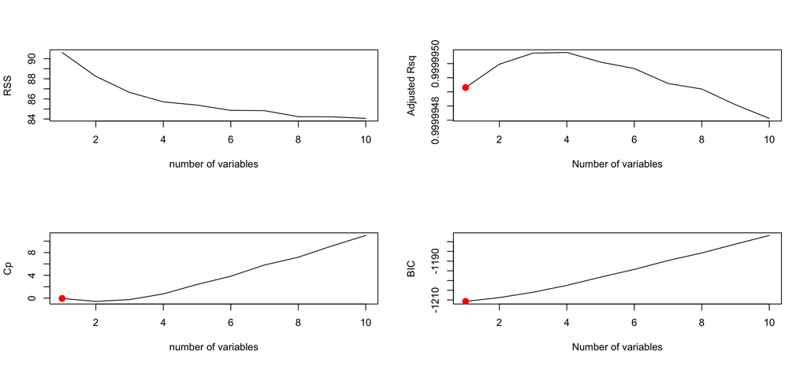

```r
points(1,abbrevmod.sum$cp[1],col="red",cex=2,pch=20)
plot(abbrevmod.sum$bic,xlab="Number of variables",ylab="BIC",type = "l")
points(which.min(abbrevmod.sum$bic), abbrevmod.sum$bic[which.min(abbrevmod.sum$bic)],col="red",cex=2,pch=20)
```

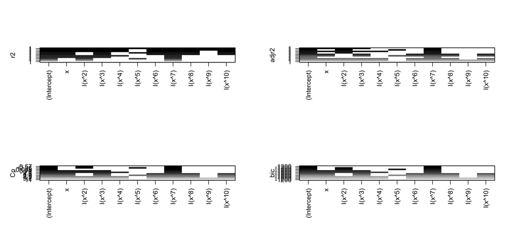

```r
plot(regfit.abbrev,scale="r2")
plot(regfit.abbrev,scale="adjr2")
plot(regfit.abbrev,scale = "Cp")
plot(regfit.abbrev,scale="bic")
```

```r
#coefficients for 1 variable model -- results don't make sense
coef(regfit.fullmodel,1)
```

```
## (Intercept)      I(x^3)
##    8.279046    8.396432
```

```r
# clearly not right
# (Intercept)      I(x^3)
# 8.279046    8.396432
coef(regfit.fullmodel,2)
```

```
## (Intercept)      I(x^2)      I(x^3)
##    5.319997    3.740657    8.050129
```

```r
# (Intercept)      I(x^2)      I(x^3)
# 5.319997    3.740657    8.050129
coef(regfit.fullmodel,3)
```

```
## (Intercept)           x      I(x^2)      I(x^3)
##    5.061507    2.975280    3.876209    7.217639
```

```r
# (Intercept)           x      I(x^2)      I(x^3)
# 5.061507    2.975280    3.876209    7.217639

#lasso - results make sense
x_matrix <- model.matrix(y ~ x + I(x^2) + I(x^3) + I(x^4) + I(x^5) + I(x^6) + I(x^7) + I(x^8) + I(x^9) + I(x^10), data = data.abbrev.set)[, -1]
crossv.lasso <- cv.glmnet(x_matrix, y, alpha = 1)
best_lamd <- crossv.lasso$lambda.min
best_lamd
```

```
## [1] 13.57478
```

```r
lasso.modl <- glmnet(x_matrix, y, alpha = 1)
lasso.coeffs=predict(lasso.modl, s = best_lamd, type = "coefficients")[1:11, ]
lasso.coeffs
```

```
## (Intercept)           x      I(x^2)      I(x^3)      I(x^4)      I(x^5)
##    5.904188    0.000000    0.000000    0.000000    0.000000    0.000000
##      I(x^6)      I(x^7)      I(x^8)      I(x^9)     I(x^10)
##    0.000000    6.776797    0.000000    0.000000    0.000000
```

```r
lasso.coeffs[lasso.coeffs!=0]
```

```
## (Intercept)      I(x^7)
##    5.904188    6.776797
```

```r
# (Intercept)      I(x^7)
# 5.904188    6.776797
```

## Problem 2: Regularization

Crime data continuation: We use a subset of the crime data discussed in class, but only look at Florida and California. `crimedata` is available on Canvas; we show the code to clean here.

```r
crime <- read.csv("CrimeData.csv", stringsAsFactors = F, na.strings = c("?"))
crime <- dplyr::filter(crime, state %in% c("FL", "CA"))
```

Our goal is to find the factors which relate to violent crime. This variable is included in crime as `crime$violentcrimes.perpop`.

**A)** **EDA**

- Clean the data first

#### Exploration & data cleaning:

```r
#names(crime)
dim(crime) #369 communities x 147 variables
sum(is.na(crime)) #7204 NA entries
#dim(na.omit(crime)) #would leave 0 communities

# =============================data1 subset==============================
data1<- crime[,c(2,6:103,121,122,123,130:147)] #subset removing sparse police dept info
#names(data1)
names(data1[, 103:120]) #crime variables
sapply(data1, function(x) any(is.na(x))) # T/F for each var
apply(data1, 2, function(x) any(is.na(x)))  # column-wise missing
apply(data1, 1, function(x) any(is.na(x)))  # row-wise missing
sum(is.na(data1$violentcrimes.perpop)) #1 NA entry
var_names_out <- c("num.urban","other.percap", "num.underpov",
                   "num.vacant.house","num.murders","num.rapes",
                   "num.robberies", "num.assaults", "num.burglaries",
                   "num.larcenies", "num.autothefts", "num.arsons")
data1 <- data1[!(names(data1) %in% var_names_out)]
names_other_crimes <- c( "murder.perpop", "rapes.perpop",
                        "robberies.perpop",  "assaults.perpop",
                        "burglaries.perpop", "larcenies.perpop",
                        "autothefts.perpop", "arsons.perpop",
                         "nonviolentcrimes.perpop")

# =============================data2 subset==============================
data2 <- data1[!(names(data1) %in% names_other_crimes)] #removing all other crime data
dim(data2) #369 communities x 99 variables

# =============================data3 subset==============================
sum(is.na(data2)) #1 NA to remove
data3 <- na.omit(data2)
dim(data3) #368 communities x 99 variables
#write.csv(data3, "CrimeData_CA_FL_clean.csv", row.names = FALSE) #optional file creation of cleaned FL & CA data
names(data3)
```

#### Histogram

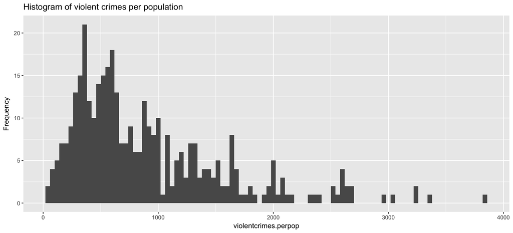

```r
ggplot(data1, aes(x = violentcrimes.perpop)) +
  geom_histogram(binwidth = 40) +
  ggtitle("Histogram of violent crimes per population") +
  ylab("Frequency") #peaks between 250 & 750
```

```r
#rownames(data1)[is.na(data1$violentcrimes.perpop)]
```

- Prepare a set of sensible factors/variables that you may use to build a model
- Show the heatmap with mean violent crime by state. You may also show a couple of your favorate summary statistics by state through the heatmaps.

### Heatmaps

* (code chunks in .rmd file)

#### Violent Crime

```
## # A tibble: 2 x 2
##   state mean.violentcrime
##   <chr>             <dbl>
## 1    CA          810.4694
## 2    FL         1159.0469
```

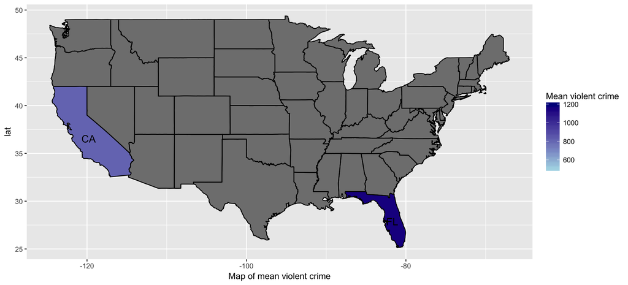

#### Percent Unemployment

```
## # A tibble: 2 x 2
##   state mean.unemployed
##   <chr>           <dbl>
## 1    CA        6.353705
## 2    FL        5.713444
```

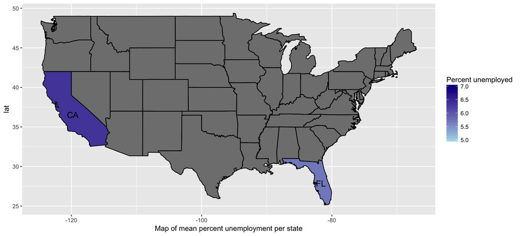

#### Percent of population with children and never married

```
## # A tibble: 2 x 2
##   state mean.kidsnvrmarried
##   <chr>               <dbl>
## 1    CA            3.390072
## 2    FL            3.950000
```

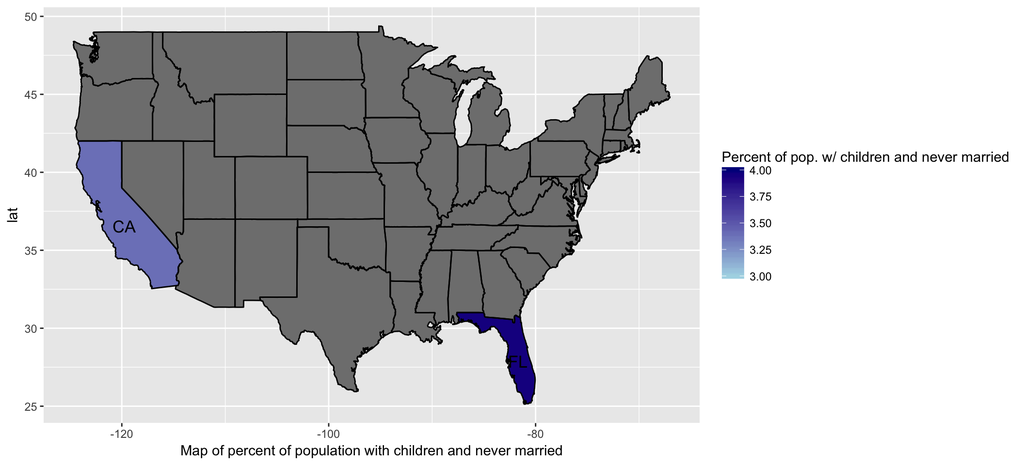

**B)** **Use LASSO to choose a reasonable, small model. Fit an OLS model with the variables obtained. The final model should only include variables with p-values < 0.05. Note: you may choose to use lambda 1se or lambda min to answer the following questions where apply.**

#### Using a given lambda

```r
#data3
#data3[, 99]
#data3$violentcrimes.perpop
Y <- data3$violentcrimes.perpop # extract Y
X <- model.matrix(violentcrimes.perpop~., data=data3)[, -1]
#colnames(X)

#============using given λ==================
fit.lambda <- glmnet(X,Y,alpha=1,lambda = 100)
names(fit.lambda)
fit.lambda$lambda # lambda used
fit.lambda$beta
fit.lambda$df    # number of non-zero coeff's -- 3 features
fit.lambda$a0 # beta_0 -- 1836.963
coef(fit.lambda) # beta hat of predictors in the original scales, same as fit.lambda$beta

# more advanced way to extract non-zero output
tmp_coeffs <- coef(fit.lambda)  # output the LASSO estimates
tmp_coeffs
```

```r
data.frame(name = tmp_coeffs@Dimnames[[1]][tmp_coeffs@i + 1], coefficient = tmp_coeffs@x) # list non-zero variables
```

```
##                  name coefficient
## 1         (Intercept) 1836.962939
## 2       race.pctblack    8.745629
## 3    pct.kids2parents  -18.807627
## 4 pct.kids.nvrmarried   80.625980
```